# Introduction

## Objectives:

- Review the ideas of computer science, programming, and problem solving.
- To understand abstraction and the role it plays in the problem solving process.
- To understand and implement the notion of an abstract data type.
- To review the Python programming language.

## What's computer science?

Computer Science is the study of problems, problem-solving, and the solutions that come out from the problem-solving process. It is very common to include the word **computable** when describing problems and solutions. We say that a problem is **computable** if an algorithm exist for solving it.

We can also say that computer science is the study of the existence and nonexistence of algorithms. CS as it pertains to the problem-solving process itself, is also the study of **abstration**.

**Abstraction** allows us to view the problem and solutions in such a way as to separate the so-called logical and physical perspectives. Consider this example with python as an abstraction element:

```python
import math
math.sqrt(16)
```

```
4.0
```

Once we import the module, we can perform computations such as the above one. This is an example of **procedual abstraction**, we do not necessarily know how the square root is being calculated, but we know that the function is called and how to use it. This sometimes is refered as a *black box*.

**Abstract Data Type (ADT)** is a logical description of how we view the data and the operations that are allowed without regard to how they will be implemented. This means that we are concerned only with what data is representing and not with how it will eventually be contructed. By providing this level of **abstraction**, we are creating an *encapsulation* around the data.

The idea is that by *encapsulating* the details of implementation, we are hiding them from the user's view. This is called **information hiding**.

The implementation of an **ADT**, often referred to as **data structure**, will require that we provide a physical view of the data using some collection of programming constructs and primitive data types.

## Built-in Atomic Data Types in Python

Python has two main bulit-in numeric classes that implement the integer and floating point data types `int` `float`. We can use operators with them:

```python
print(2+3*4)
print((2+3)*4)
print(2**10)
print(6/3)
print(7/3)
print(7//3)
print(7%3)
print(3/6)
print(3//6)
print(3%6)
print(2**100)
```

```
14
20
1024
2.0
2.3333333333333335
2
1
0.5
0
3
1267650600228229401496703205376
```

The **boolean** data type, implemented as the Python `bool` class works with truth values:

```python
print(True)
print(False)
print(False or True)
print(not(False or True))
print(True and True)
```

```
True
False
True
False
True
```

The booleans are also used with `==` as equality and greater than `>`. In addition, relational operators and logical operators can be combined together to form complex logical questions.

```python
print(5==10)
print(10>5)
print((5>=1)and(5<=10))
```

```
False
True
True
```

**Identifiers** are used in programming languages as names. In Python identifiers start with a letter or underscore, are case sensitive, and can be of any length.

```python
# variables hold references of data objects
theSum = 0
print(theSum)

# this assignment changes the reference
theSum = theSum + 1
print(theSum)

theSum = True
print(theSum)
```

```
0
1
True
```

## Built-in Collection Data Types

Python has a powerfull collection of built in classes:

- List - ordered collection of zero or more references to Python data objects.
- String - sequential collections of zero or more letters, numbers and other symbols, we call all these objects *characters*.
- Tuples - tuples are very similar to lists, the difference is that it is immutable, like a string.

These three are ordered collections that are very similar in general structure.

```python
myList = [1,2,3,4]
print(myList)
print(type(myList))

print("")

myString = 'Hello World 25'
print(myString)
print(type(myString))

print("")

myTuple = ('Ed',1,2,'Hello World 25','&')
print(myTuple)
print(type(myTuple))
```

```
[1, 2, 3, 4]
<class 'list'>

Hello World 25
<class 'str'>

('Ed', 1, 2, 'Hello World 25', '&')
<class 'tuple'>
```

### Lists Methods

```python
myList = [1024, 3, True, 6.5]
print(myList,'\n')

# append - Adds a new item to the end of the list - alist.append(item)
myList.append(False)
print(myList,'\n')

# insert - Insert an item in the ith position in a list - alist.insert(i, item)
myList.insert(2, 4.5)
print(myList,'\n')

# pop - Removes and returns the last item in a list - alist.pop()
myList.pop()
print(myList,'\n')

# pop(i) - Removes and returns the ith item in a list - alist.pop(i)
myList.pop(1)
print(myList,'\n')

# sort - Modifies a list to be sorted - alist.sort()
myList.sort()
print(myList,'\n')

# reverse - Modifies a list to be in reverse order - alist.reverse()
myList.reverse()
print(myList,'\n')

# count - Returns the number of occurence of item - alist.count(item)
myList.count(6.5)
print(myList,'\n')

# index - Returns the index of the first ocurrence of item - alist.index(item)
myList.index(4.5)
print(myList,'\n')

# remove - Removes the first ocurrence of item - alist.remove(item)
myList.remove(6.5)
print(myList,'\n')

# Deletes the item in the ith position - del alist[i]
del myList[0]
print(myList)
```

```
[1024, 3, True, 6.5]

[1024, 3, True, 6.5, False]

[1024, 3, 4.5, True, 6.5, False]

[1024, 3, 4.5, True, 6.5]

[1024, 4.5, True, 6.5]

[True, 4.5, 6.5, 1024]

[1024, 6.5, 4.5, True]

[1024, 6.5, 4.5, True]

[1024, 6.5, 4.5, True]

[1024, 4.5, True]

[4.5, True]
```

**Dot Notation** is for asking an object to invoke a method. `myList.append(False)` can be read as *"Ask the object myList to perform append method and send it the value False"*. Check list of magic methods.

```python
# even simple data objects such as integers
# can invoke methods this way
print((54).__add__(21))
print((54).__sub__(21))
print((54).__mul__(21))
print((54).__floordiv__(21))
print((54).__truediv__(21))
print((54).__mod__(21))
print((54).__pow__(21))
print((54).__lshift__(21))
print((54).__rshift__(21))
print((54).__and__(21))
print((54).__xor__(21))
print((54).__or__(21))
```

```
75
33
1134
2
2.5714285714285716
12
2400318963698027714075059177761275904
113246208
0
20
35
55
```

One common Python function `.range` produce a range of objects that represent a sequence of values. By using the `list` function, it is possible to see the value of the range object as a list:

```python
print(range(10))
print(list(range(10)))
print(range(5,10))
print(list(range(10)))
print(list(range(5,10,2)))
print(list(range(10,1,-1)))
```

```
range(0, 10)
[0, 1, 2, 3, 4, 5, 6, 7, 8, 9]
range(5, 10)
[0, 1, 2, 3, 4, 5, 6, 7, 8, 9]
[5, 7, 9]
[10, 9, 8, 7, 6, 5, 4, 3, 2]
```

### Strings Methods

```python
myString = 'Eduardo'
print(myString)

# center - Returns a string center in a field of size w - astring.center(w)
print(myString.center(10))

# count - Returns the number of occurences of item in the string - astring.count(item)
print(myString.count('d'))

# ljust - Returns a string left justified in a field of size w - astring.ljust(w)
print(myString.ljust(10))

# lower - Returns a string in lowercase - astring.lower()
print(myString.lower())

# rjust - Returns a string right justified in a field of size w - astring.rjust(w)
print(myString.rjust(10))

# find - Returns the index of the first occurence of item - astring.find(w)
print(myString.find('E'))

# split - Splits a string into sub-strings at schar - astring.split(schar)
print(myString.split('d'))
```

```
Eduardo
 Eduardo
2
Eduardo
eduardo
   Eduardo
0
['E', 'uar', 'o']
```

#### String Formatting

We can change the behavior of how a string is shown, it id often used to have more control over the look of your output.

```python
print('Hello')
print('Hello', 'World')
print('Hello', 'World', sep='***')
print('Hello', 'World', end='***')
```

```
Hello
Hello World
Hello***World
Hello World***
```

Formatted string is a template in which words and spaces that will remain constant are combined with placeholders for variables that will be inserted into the string. For example, the statement.

```python
aName = input('Please enter your name ')
print("Your name in all capitals is", aName.upper(), 'and has length of', len(aName))
```

```
Please enter your name eduardo
Your name in all capitals is EDUARDO and has length of 7
```

| Character | Output Format |
| --- | --- |
| `d,i` | Integer |
| `u` | Unsigned integer |
| `f` | Floating point as m.ddddd |
| `e` | Floating point as m.ddddde+/-xx |
| `E` | Floating point as m.dddddE+/-xx |
| `g` | Use %e for exponents less than -4 or greater than +5, otherwise use %f |
| `c` | Single character |
| `s` | String, or any Python data object that can be converted to a string by using the str function |
| `%` | Insert a literal % object |

```python
name = 'Edoard'
age = 33
print('%s is %d yeard old.' % (name, age))
```

```
Edoard is 33 yeard old.
```

New python version allow this type of formatting, which is easier:

```python
print(f'{name} is {age} years old')
```

```
Edoard is 33 years old
```

In addition to the format character you can also include a format modifier between the `%` and the format character.

| Character | Output Format | Description |
| --- | --- | --- |
| Number | `%20d` | Put the value in a field width of 20 |
| - | `-%20d` | Put the value in a field of 20 characters wide, left justified |
| + | `+%20d` | Put the value in a field of 20 characters wide, right justified |
| `0` | `%020d` | Put the value in a field of 20 characters wide, filled in with leading zeros |
| `.` | `%20.2f` | Put the value in a field of 20 characters wide, with two characters to the right of the decimal point |
| `(name)` | `%(name)d` | Get the value from the supplied dictionary using `name` as the key. |

```python
price = 24
item = 'banana'

print("The %s costs %d cents" % (item,price),"\n")
print("The %+10s costs %5.2f cents" % (item, price), "\n")
print("The %+10s costs %10and.2f cents" % (item, price), "\n")

itemdict = {'item':'banana', 'cost':24}
print('The %(item)s costs %(cost)7.1f cents'%itemdict)
```

```
The banana costs 24 cents

The     banana costs 24.00 cents

The     banana costs         24nd.2f cents

The banana costs    24.0 cents
```

### Sets

A set is an unordered collection of zero or more immutable Python data objects. Sets do not allow duplicates and are written as comma-delimited values enclosed in curly braces. The empty set is represented by `set()`. Sets are heterogenous and the collection can be assigned to a variable as below.

```python
type({3,6,'hello', 4.5, False})
```

```
set
```

Even though set aren't sequential, they do support a few of the familiar operators presented above.

```python
a = {1,'hello', 4.5, False}
b = {1, 2, 'hello','bye'}

print(4.5 in a) # membership
print(a | b) # returns values from moth sets, no duplicates
print(a & b) # returns just the values that are in both sets
print(a - b) # returns only the values from set a but not from b
print(a <= b)# asks whether all elements of the first set are in the second one
print(a.union(b)) # merges 2 sets
print(a.intersection(b)) # check for intersections in both sets
print(a.difference(b)) # returns only the values from set a but not from b same as - method
print(a.pop()) # Removes an arbitrary element from the set
print({1,'hello'}.issubset(a)) # checks if the items are subsets of any set
a.add('house') # add house to set a
print(a)
b.clear() # clears the set
print(b)
```

```
True
{False, 1, 2, 4.5, 'bye', 'hello'}
{1, 'hello'}
{False, 4.5}
False
{False, 1, 2, 4.5, 'bye', 'hello'}
{1, 'hello'}
{False, 4.5}
False
True
{'house', 1, 4.5, 'hello'}
set()
```

### Dictionaries

Dictionaries are **unordered** collections of associated pairs of items which each pair consist of a key and a value. Dictionaries have both methods and operators.

```python
capitals = {'Iowa':'Des Moines', 'Wisconsin':'Madison', 'California':'Sacramento'} # define a dictionary
capitals['Utah'] = 'Salt Lake City' # adds a value
print(capitals)
print(len(capitals)) # length of capitals

# [] - This operator selects the value associated with the key - myDict[]
print(capitals['Iowa'])

# in - Returns True if key is in the dictionary, False otherwise - key in dict
print('Quebec' in capitals)

# del - Removes the entry from the dictionary - del.adict[key]
del capitals['Iowa']
print(capitals)

# keys() - Shows all the keys in the dict - myDict.keys()
print(capitals.keys())
print(list(capitals.keys())) # eliminates the dict_keys object pointer at the beggining

# values() - Returns the values in the dictioanry - myDict.values()
print(capitals.values())
print(list(capitals.values())) # eliminates the dict_keys object pointer at the beggining

# items() - Shows every pair key val segmented in parenthesis
print(list(capitals.items()))

# get() - Returns the value associated with k, None otherwise - myDict.get(k)
print(capitals.get('Quebec'))
print(capitals.get('Quebec', 'No Entry')) # changes the default None to string especified
```

```
{'Iowa': 'Des Moines', 'Wisconsin': 'Madison', 'California': 'Sacramento', 'Utah': 'Salt Lake City'}
4
Des Moines
False
{'Wisconsin': 'Madison', 'California': 'Sacramento', 'Utah': 'Salt Lake City'}
dict_keys(['Wisconsin', 'California', 'Utah'])
['Wisconsin', 'California', 'Utah']
dict_values(['Madison', 'Sacramento', 'Salt Lake City'])
['Madison', 'Sacramento', 'Salt Lake City']
[('Wisconsin', 'Madison'), ('California', 'Sacramento'), ('Utah', 'Salt Lake City')]
None
No Entry
```

## Control Structures

Algorithms require two important control structures:

- **Iteration** - Python provides a standard *while* statement and a very powerful *for statement*
- **Selection** - They allow the programmer to ask questions, and then based on the result, perform different actions.

### Iteration examples

```python
# While loop
counter = 1

# while the condition remains true print hello world
while counter <= 5:
    print('Hello, world!')
    # add the counter to 1, then repeat
    counter += 1
```

```
Hello, world!
Hello, world!
Hello, world!
Hello, world!
Hello, world!
```

```python
# for loop that asigns the variable item to be each
# successive value in the list [1,3,6,2,5].
# This works for any collection that is a sequence(list, tuples and strings)
for item in [1,3,6,2,5]:
    print(item)
```

```
1
3
6
2
5
```

A common use of the `for` statement is to implement definite iteration over a range of values. The statement

```python
for item in range(5):
    print(item**2)
```

```
0
1
4
9
16
```

```python
wordlist = ['cat', 'dog', 'rabbit']
letterlist = []
for aword in wordlist:
    for aletter in aword:
        letterlist.append(aletter)

letterlist
```

```
['c', 'a', 't', 'd', 'o', 'g', 'r', 'a', 'b', 'b', 'i', 't']
```

### Selection examples

Most programming languages provide two versions of this useful construct: the `ifelse` and the `if`.

```python
import math

n = 9

if n <0:
    print('Sorry, value is negative')
else:
    print(math.sqrt(n))
```

```
3.0
```

```python
score = 90

if score >= 90:
    print('A')
elif score >= 80:
    print('B')
elif score >= 70:
    print('C')
elif score >= 60:
    print('D')
else:
    print('F')
```

```
A
```

Python also has a single way selection construct, the `if` statement. With this statement, if the condition is `True`, an action is performed; in the case the condition is `False`, processing simply continues on to the next statement after the `if`.

```python
n = -9

if n<0:
    n = abs(n)
    print(math.sqrt(n))
```

```
3.0
```

### List Comprehension

List comprehension use iterartion to select contructs; they allows us to create a list based on some processing or some selection criteria.

```python
# the variable x takes on valiue 1 to 10 as especified by the "for" construct
sqlist = [x*x for x in range(1,11)]
sqlist
```

```
[1, 4, 9, 16, 25, 36, 49, 64, 81, 100]
```

```python
# selects all odd numbers from 1 to 10 and multiply them by themselves
sqlist = [x*x for x in range(1,11) if x % 2 != 0]
sqlist
```

```
[1, 9, 25, 49, 81]
```

```python
# Any sequence that supports iteration can be used within a list
# comprehension to construct a new list
[ch.upper() for ch in 'comprehension' if ch not in 'aeiou']
```

```
['C', 'M', 'P', 'R', 'H', 'N', 'S', 'N']
```

## Exception Handling

There are two types of errors that typically occur when writting programs.

- **Syntax error** - mistake in the structure of statement or expression.
  - for example write a for statement and forget the `:`
- **Logic error** - the programs executes but gives the wrong result. The logic error causes a **runtime error** which causes the program to terminate. **runtime errors** are usually called **exceptions**.
  - trying to divide by zero
  - trying access to an item in a list where the index of the item is outside the bounds of the list

```python
# Python interpreter has found that it cannot complete the processing
# of this instruction since it does not conform to the rules of the language.
for i in rannge(1,10)
    print(i)
```

```
  File "<ipython-input-29-ba0e03910c11>", line 3
    for i in rannge(1,10)
                         ^
SyntaxError: invalid syntax
```

```python
# index outside the bounds of the list
items = [1,2,'hello', True]
items[4]
```

```
---------------------------------------------------------------------------
IndexError                                Traceback (most recent call last)
<ipython-input-30-995f6a3376e1> in <module>
      1 items = [1,2,'hello', True]
----> 2 items[4]

IndexError: list index out of range
```

```python
# dividing by zero
2/0
```

```
---------------------------------------------------------------------------
ZeroDivisionError                         Traceback (most recent call last)
<ipython-input-31-e8326a161779> in <module>
----> 1 2/0

ZeroDivisionError: division by zero
```

```python
# math.sqrt can square negative numbers
anumber = int(input("Please enter an integer: "))
print((math.sqrt(anumber)))
```

```
Please enter an integer: -2
```

```
---------------------------------------------------------------------------
ValueError                                Traceback (most recent call last)
<ipython-input-32-52f66ad62640> in <module>
      1 anumber = int(input("Please enter an integer: "))
----> 2 print((math.sqrt(anumber)))

ValueError: math domain error
```

### exception statemtent

We can handle the above **exception** by calling the `print` function from within a `try` block. A corresponding `except` block "catches" the exception and prints a message back to the user in the event that an **exception** occurs:

```python
anumber = int(input("Please enter an integer: "))

try:
    print(math.sqrt(anumber))
except:
    print('Bad Value for square root')
    print(f'Using absolute value of {anumber} instead')
    print(math.sqrt(abs(anumber)))
```

```
Please enter an integer: -2
Bad Value for square root
Using absolute value of -2 instead
1.4142135623730951
```

The **except** statement in this case is catching the fact that an exception is raised by `sqrt` and will print the message back to the user and use the absolute value instead. This means that the program will not terminate but instead will continue on to the next statements.

### raise statement

It is also possible to cause a **runtime error** by using the `raise` statement. Instead of calling the square root function with a negative number, we could have check the value first and then raised our own **exception**. Note that the next program will terminate but now the exception that caused the termination is something explicitly created by the programmer.

```python
anumber = int(input("Please enter an integer: "))

if anumber < 0:
    raise RuntimeError("You don't want to use a negative number")
else:
    print(math.sqrt(anumber))
```

```
Please enter an integer: -2
```

```
---------------------------------------------------------------------------
RuntimeError                              Traceback (most recent call last)
<ipython-input-34-ad57e2dccc38> in <module>
      2
      3 if anumber < 0:
----> 4     raise RuntimeError("You don't want to use a negative number")
      5 else:
      6     print(math.sqrt(anumber))

RuntimeError: You don't want to use a negative number
```

There are many kinds of **exceptions** that can be raised in addtion to the `RuntimeError`. Python has a list of all the available exception types and how to create your own ones. Check Python's documentation for more information.

## Functions

The earlier example of **procedual abstraction** with the `sqrt` from the `math` module shows us how we can hide the details of any computation by defining a function. A function definition requires a `name`, `parameter(s)`, and `body`.

```python
def square(n): # name and parameter
    # detailes hidden inside the box, in this case n**2
    return n**2 # body

print(square(3))
print(square(square(3)))
```

```
9
81
```

We could implement our own square root function by using a well known technique called "Newton's Method" for approximating square roots by performing an iterative computation that converges on the correct value.

```python
def squarerrot(n):
    root = n/2 # initial guess will be 1/2 of n
    for k in range(20):
        root = (1/2) * (root + (n / root))

    return root

print(squarerrot(81))
print(squarerrot(squarerrot(81)))
```

```
9.0
3.0
```

## Object Oriented Programming

**NOTE: The OOP part is more dense than the above sections, that's why there are parts in this section that I copy paste directly from the book for a better understanding of the whole concept. I think it's very easy to miss details and understanding when taking about classes, instances, etc.**

Python is an object-oriented programming language. So far we've used a number of built-in classes to show examples of data and control-structures. One of the most powerful features in the OOP is the ability to allow a programmer to create new classes that model data that is needed to solve the problem.

We used ADT to provide the logical descriptions of what a data object looks like (its state) and what it can do (its methods). By building a class that implements an abstract data type, a programmer can take advantage of the abstraction process and at the same time provide the details neccessary to actually use the abstraction in a program. Whenever we want to implement an ADT, we will do so with a new class.

### A `Fraction` Class

A very common example to show the details of implementing a user-defined class is to construct a class to implement the abstract data type `Fraction`. Python provides a number of numeric classes for our use, however, there are times that it would be most appropiate to be able to create data objects that "look like fractions".

Fractions consist of two values:

- Top value (numerator) and it can be any integer.
- Bottom value (denominator) and it can be any integer greater that 0. Negative fractions have negative numerator.

The operations for the `Fraction` type will allow `Fraction` data object to behave like any other numeric value: add, substract, multiply, and divide fractions. We also want to be able to represent this with their "slash" form: `3/4`. In addition all fractions methods should return results in their lowest termns so that no matter what computation is performed, we always end with the most simplified form.

In python we difine a new class by providing a `name` and a set of `method` definitions.

#### Breakdown of the class object

- Notice that we have three parameters, `self` is a especial parameter that will **always** be used as a reference back to the object itself. It must always be the first formal parameter, however, it will never be given an actual parameter value upon invocation.
- The notation `self.num` in the constructor defines the `fraction` object to have an internal data object called `num` as part of its state. Likewise `self.den` creates the denominator.

The values of the two formal parameters are initially assigned to the state, allowing the new `fraction` object to know its starting value.

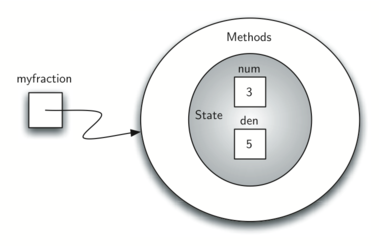

To create an instance of the `Fraction` class, we must invoke the constructor. We do it by using the name of the class and passing actual values for the necessary state (note that we never directly invoke `__init__`).

```python
class Fraction:

    # method

    def __init__(self, top, bottom):
        self.num = top
        self.den = bottom

myFraction = Fraction(3,5)
print(myFraction)
```

```
<__main__.Fraction object at 0x10a891ac8>
```

The `print` function requires that the object convert itself into a string so that the string can be written to the output. We only see the reference `<__main__.Fraction object at 0x1069422b0>` that is store in a variable, this is not what we want.

- We need to define a method called `show` that will allow the `Fraction` object to print itself as a string

```python
class Fraction:

    # methods

    def __init__(self, top, bottom):
        self.num = top
        self.den = bottom


    def show(self):
        print(self.num, '/', self.den)

myFraction = Fraction(3,5)
```

```python
myFraction.show()
```

```
3 / 5
```

```python
print(myFraction)
```

```
<__main__.Fraction object at 0x10bbd1208>
```

Unfortunately that doesn't work in general. In order to make printing work properly we need to tell `Fraction` class how to convert itself into a string.

In Python all clases have a set of standard methods that are provided but may not work properly. One of these is `__str__` is the method to convert an object into a string. What we need to do is provide a "better" implementation for this method. We will say that this method overrides the previous one.

To do this we define a method with the name `__str__` and gice a new implementation. This definition doesn't need any other information except the special parameter `self`.

```python
class Fraction:

    # methods

    def __init__(self, top, bottom):
        self.num = top
        self.den = bottom

    def show(self):
        print(self.num, '/', self.den)


    def __str__(self):
        return str(self.num) + "/" + str(self.den)
```

```python
myFraction = Fraction(3, 5)
```

```python
print(myFraction,'\n')
print("I ate", myFraction, "of the pizza")
```

```
3/5

I ate 3/5 of the pizza
```

```python
myFraction.__str__()
```

```
'3/5'
```

```python
str(myFraction)
```

```
'3/5'
```

At this point if we try to add two fractions, we get the following `TypeError`:

```python
f1 = Fraction(1, 4)
f2 = Fraction(1, 4)
f1 + f2
```

```
---------------------------------------------------------------------------
TypeError                                 Traceback (most recent call last)
<ipython-input-84-14151b324a0d> in <module>
      1 f1 = Fraction(1, 4)
      2 f2 = Fraction(1, 4)
----> 3 f1 + f2

TypeError: unsupported operand type(s) for +: 'Fraction' and 'Fraction'
```

The problem is that the `+` operator doesn't understand the `Fraction` operands. We can fix this by providing the `Fraction` class with a method that overrides the addition method.

Two fractions must have the same denominator to de added. The easiest way to make sure they have the same denominator is to use the product of the two denominators as a common denominator.

```python
class Fraction:

    # method

    def __init__(self, top, bottom):
        self.num = top
        self.den = bottom


    def __str__(self):
        return str(self.num) + "/" + str(self.den)

    def __add__(self, otherfraction):
        newnum = self.num * otherfraction.den + self.den * otherfraction.num
        newden = self.den * otherfraction.den

        return Fraction(newnum, newden)
```

```python
f1 = Fraction(1, 4)
f2 = Fraction(1, 2)
f3 = f1 + f2
print(f3)
```

```
6/8
```

As we can see `6/8` is not simplified, `3/4` should be the answer. To fix this we need a helper function that knows how to reduce fractions. This function will need to look for the greatest common divisor. The best-known algorithm for finding a greatest common divisor is Euclid's algorithm.

Euclid's algorithm states that the greatest common divisor (GCD) of two integers `m` and `n` is `n` if `n` divides `m` evenly. However if `n` doesn't divide `m` evenly, then the answer is the GCD of `n` and the remainder of `m` divided by `n`.

```python
# helper function
def gcd(m, n):
    while m%n != 0:
        oldm = m
        oldn = n

        m = oldn
        n = oldm%oldn
    return n

class Fraction:

    def __init__(self, top, bottom):
        self.num = top
        self.den = bottom


    def __str__(self):
        return str(self.num) + "/" + str(self.den)


    def __add__(self, otherfraction):
        newnum = self.num * otherfraction.den + self.den * otherfraction.num
        newden = self.den * otherfraction.den
        common = gcd(newnum, newden)
        return Fraction(newnum // common, newden // common)

        return Fraction(newnum, newden)
```

```python
f1 = Fraction(1, 4)
f2 = Fraction(1, 2)
f3 = f1 + f2
print(f3)
```

```
3/4
```

Our Fraction object now has two very useful methods and looks like the Figure below. An additional group of methods that we need to include in our example `Fraction` class will allow two fractions to compare themselves to one another. Assume we have two `Fraction` objects, `f1` and `f2`. `f1==f2` will only be `True` if they are references to the same object. Two different objects with the same numerators and denominators would not be equal under this implementation. This is called **shallow equality**.

**Fraction class with two methods**

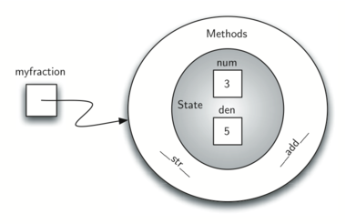

We can create deep equality by the same value, not the same reference–by overriding the `__eq__` method. The `__eq__` method is another standard method available in any class. The `__eq__` method compares two objects and returns True if their values are the same, False otherwise.

In the Fraction class, we can implement the `__eq__` method by again putting the two fractions in common terms and then comparing the numerators. It is important to note that there are other relational operators that can be overridden. For example, the `__le__` method provides the less than or equal functionality.

```python
def gcd(m,n):
    while m%n != 0:
        oldm = m
        oldn = n

        m = oldn
        n = oldm%oldn
    return n

class Fraction:
     def __init__(self,top,bottom):
         self.num = top
         self.den = bottom

     def __str__(self):
         return str(self.num)+"/"+str(self.den)

     def show(self):
         print(self.num,"/",self.den)

     def __add__(self,otherfraction):
         newnum = self.num*otherfraction.den + \
                      self.den*otherfraction.num
         newden = self.den * otherfraction.den
         common = gcd(newnum,newden)
         return Fraction(newnum//common,newden//common)

     def __eq__(self, other):
         firstnum = self.num * other.den
         secondnum = other.num * self.den

         return firstnum == secondnum

x = Fraction(1,2)
y = Fraction(1,2)
print(x+y)
print(x == y)
```

```
1/1
True
```

**Shallow Equality vs Deep Equality**

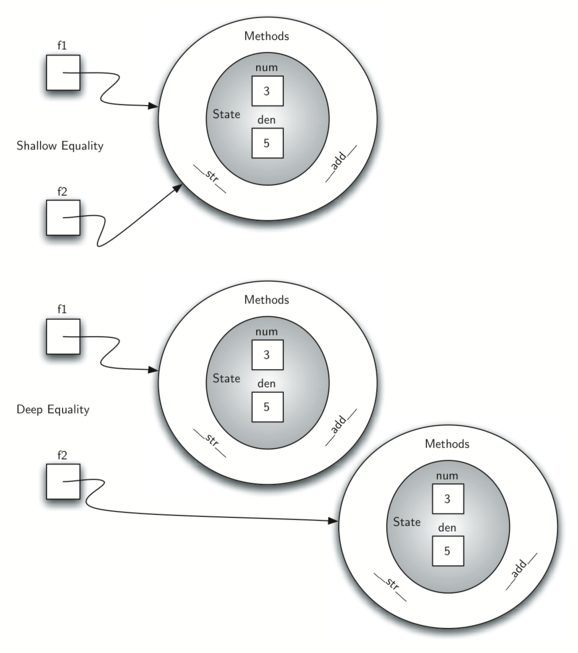

#### Inheritance: Logic Gates and Circuits

**Inheritance** is the abiity for one class to be related to another class in much the same way that people can be related to one another. Children inherit characteristics from their parents. Similarly, Python child classes can inherit characteristic data and behavior from a parent class. The classes are often referred to as **subclasses** or **superclasses**.

We call a relationship structure such as this an **inheritance hierarchy**. For example, the `list` is a child of the sequential collection. In this case, we call the `list` the child and the sequence the parent (or subclass list and superclass sequence). This is often referred to as an **IS-A-Relationship** (the list **IS-A** sequential collection).

Lists, tuples, and strings are all types of sequential colections. They all inherit common data organization and operations. However, each of them is distinct based on whether the data is homogeneous and whether the collection is immutable. The children all gain from their parents but distinguish themselves by adding additional characteristics.

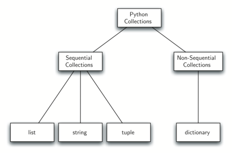

Let's take a look at how the `Fraction` class looks completed:

```python
class Fraction:

    def __init__(self, top, bottom):
        self.num = top
        self.den = bottom


    def __str__(self):
        return str(self.num) + "/" + str(self.den)


    def show(self):
        print(self.num , '/', self.den)


    def __add__(self, otherfraction):
        newnum = self.num * otherfraction.den + self.den * otherfraction.num
        newden = self.den * otherfraction.den
        common = gcd(newnum, newden)
        return Fraction(newnum // common, newden // common)

    def __eq__(self, other):
        firstnum = self.num * other.den
        secondnum = other.num * self.den

        return firstnum == secondnum
```

By organizing classes in this hierarchical fashion, object-oriented programming languages allow previously written code to be extended to meet the needs of a new situation. We can understand relationships that exist and has more efficiency in building our absract representation.

#### Digital Circuits Simulation

The basic building block for this simulation will be the **logic gate**. These electronic switches represent boolean algebra relationships betwen their input and their output. In general gates have a single output line. The value of the output is dependent on the vaule given on the input lines.

- **AND** gates have two lines, each of which can be either 0 or 1 (False or True).
- **OR** gates also have two input lines and produce a 1 if one or both of the inputvalues is 1.
- **NOT** gates differ from the other 2, they only have a single input line, if 0 appears on the input, 1 is produced on the output.

Let's check this Figure for a better understanding:

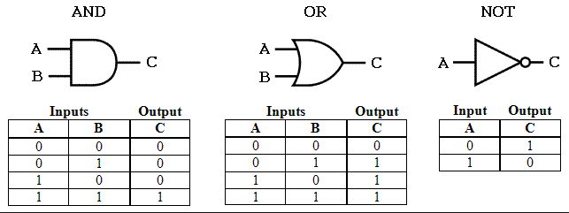

By combining these gates in various patterns and then applying a set of input values, we can build circuits that have logocal functions.

The output lines from the two **AND** gates feed directly into the **OR** gate, and the resulting output from the **OR** gate is given to the **NOT** gate.

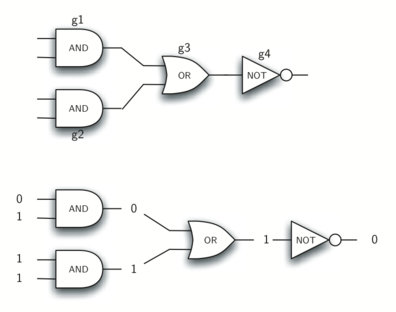

In order to implemet a circuit, we will first build a representation for the logic gates. Logic gates are easily organized into a **class inheritance hierarchy**; at the top of the hierarchy, the `LogicGate` class represents the most general characteristics of logic gates: namely, a label for the gate and an output line. The next level of subclasses breaks the logic gates into two families, those that have one input line and those that have two.

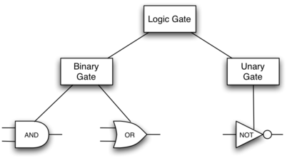

We can now start to implement the classes by starting with the most general, `LogicGate`. As noted earlier, each gate has a label for identification and a single output line. In addition, we need methods to allow a user of a gate to ask the gate for its label.

The other behavior that every logic gate needs is the ability to know its output value. This will require that the gate perform the appropriate logic based on the current input. In order to produce output, the gate needs to know specifically what that logic is. This means calling a method to perform the logic computation.

At this point, we will not implement the `performGateLogic` function. The reason for this is that we do not know how each gate will perform its own logic operation. Those details will be included by each individual gate that is added to the hierarchy. This is a very powerful idea in object-oriented programming. We are writing a method that will use code that does not exist yet. The parameter `self` is a reference to the actual gate object invoking the method. Any new logic gate that gets added to the hierarchy will simply need to implement the `performGateLogic` function and it will be used at the appropriate time. Once done, the gate can provide its output value. This ability to extend a hierarchy that currently exists and provide the specific functions that the hierarchy needs to use the new class is extremely important for reusing existing code.

We categorized the logic gates based on the number of input lines. The **AND** gate has two input lines. The **OR** gate also has two input lines. **NOT** gates have one input line. The `BinaryGate` class will be a subclass of `LogicGate` and will add two input lines. The `UnaryGate` class will also subclass `LogicGate` but will have only a single input line. In computer circuit design, these lines are sometimes called “pins” so we will use that terminology in our implementation.

```python
# Super class LogicGate
class LogicGate:

    def __init__(self, n):
        self.label = n
        self.output = None

    def getLabel(self):
        return self.label

    def getOutput(self):
        self.output = self.performGateLogic()
        return self.output

# Binary gate class
class BinaryGate(LogicGate):

    def __init__(self, n):
        super().__init__(n)

        self.pinA = None
        self.pinB = None

    def getPinA(self):
        return int(input("Enter Pin A input for gate " + self.getLabel()+"-->"))

    def getPinB(self):
        return int(input("Enter Pin B input for gate " + self.getLabel()+"-->"))

# Unary gate class
class UnaryGate(LogicGate):

    def __init__(self, n):
        super().__init__(n)

        self.pin = None

    def getPin(self):
        return int(input("Enter Pin input for gate " + self.getLabel()+"-->"))
```

`BinaryGate` and `UnaryGate` implement these two classes. The constructors in both of these classes start with an explicit call to the constructor of the parent class using the parent’s `__init__` method. When creating an instance of the `BinaryGate` class, we first want to initialize any data items that are inherited from `LogicGate`. In this case, that means the label for the gate. The constructor then goes on to add the two input lines (pinA and pinB). This is a very common pattern that you should always use when building class hierarchies. Child class constructors need to call parent class constructors and then move on to their own distinguishing data.

Python also has a function called `super` which can be used in place of explicitly naming the parent class. This is a more general mechanism, and is widely used, especially when a class has more than one parent. For example in our example above `LogicGate.__init__(self,n)` could be replaced with `super(UnaryGate,self).__init__(n)`.

The only behavior that the `BinaryGate` class adds is the ability to get the values from the two input lines. Since these values come from some external place, we will simply ask the user via an input statement to provide them. The same implementation occurs for the `UnaryGate` class except that there is only one input line.

Now that we have a general class for gates depending on the number of input lines, we can build specific gates that have unique behavior. For example, the `AndGate` class will be a subclass of `BinaryGate` since `AND` gates have two input lines. As before, the first line of the constructor calls upon the parent class constructor (BinaryGate), which in turn calls its parent class constructor (LogicGate). Note that the `AndGate` class does not provide any new data since it inherits two input lines, one output line, and a label.

For more information about super: https://realpython.com/python-super/

```python
# And gate class
class AndGate(BinaryGate):

    def __init__(self,n):
        super().__init__(n)

    def performGateLogic(self):

        a = self.getPinA()
        b = self.getPinB()
        if a == 1 and b == 1:
            return 1
        else:
            return 0
```

The only thing `AndGate` needs to add is the specific behavior that performs the boolean operation that was described earlier. This is the place where we can provide the `performGateLogic` method. For an `AND` gate, this method first must get the two input values and then only return 1 if both input values are 1.

We can show the `AndGate` class in action by creating an instance and asking it to compute its output. The following session shows an `AndGate` object, g1, that has an internal label "G1". When we invoke the getOutput method, the object must first call its `performGateLogic` method which in turn queries the two input lines. Once the values are provided, the correct output is shown.

```python
g1 = AndGate('G1')
g1.getOutput()
```

```
Enter Pin A input for gate G1-->1
Enter Pin B input for gate G1-->0
```

```
0
```

The same development can be done for `OR` gates and `NOT` gates. The `OrGate` class will also be a subclass of `BinaryGate` and the `NotGate` class will extend the `UnaryGate` class. Both of these classes will need to provide their own `performGateLogic` functions, as this is their specific behavior.

We can use a single gate by first constructing an instance of one of the gate classes and then asking the gate for its output (which will in turn need inputs to be provided). For example:

```python
# And gate class
class OrGate(BinaryGate):

    def __init__(self,n):
        super().__init__(n)

    def performGateLogic(self):

        a = self.getPinA()
        b = self.getPinB()
        if a == 1 or b == 1:
            return 1
        else:
            return 0
```

```python
g2 = OrGate('G2')
g2.getOutput()
```

```
Enter Pin A input for gate G2-->0
Enter Pin B input for gate G2-->1
```

```
1
```

```python
# And gate class
class NotGate(UnaryGate):

    def __init__(self,n):
        UnaryGate.__init__(self,n)

    def performGateLogic(self):
        if self.getPin():
            return 0
        else:
            return 1
```

```python
g3 = NotGate('G3')
g3.getOutput()
```

```
Enter Pin input for gate G3-->0
```

```
1
```

Now that we have the basic gates working, we can turn our attention to building circuits. In order to create a circuit, we need to connect gates together, the output of one flowing into the input of another. To do this, we will implement a new class called `Connector`.

The `Connector` class will not reside in the gate hierarchy. It will, however, use the gate hierarchy in that each connector will have two gates, one on either end (see Figure 12). This relationship is very important in object-oriented programming. It is called the **HAS-A Relationship**. Recall earlier that we used the phrase **IS-A Relationship** to say that a child class is related to a parent class, for example `UnaryGate` **IS-A** `LogicGate`.

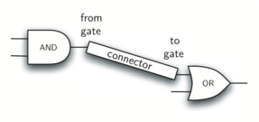

Now, with the `Connector` class, we say that a `Connector` **HAS-A** `LogicGate` meaning that connectors will have instances of the `LogicGate` class within them but are not part of the hierarchy. When designing classes, it is very important to distinguish between those that have the **IS-A relationship** (which requires inheritance) and those that have **HAS-A relationships** (with no inheritance).

The two gate instances within each connector object will be referred to as the fromgate and the togate, recognizing that data values will “flow” from the output of one gate into an input line of the next. The call to `setNextPin` is very important for making connections. We need to add this method to our gate classes so that each togate can choose the proper input line for the connection.

```python
class Connector:

    def __init__(self, fgate, tgate):
        self.fromgate = fgate
        self.togate = tgate

        tgate.setNextPin(self)

    def getFrom(self):
        return self.fromgate

    def getTo(self):
        return self.togate
```

In the `BinaryGate` class, for gates with two possible input lines, the connector must be connected to only one line. If both of them are available, we will choose `pinA` by default. If `pinA` is already connected, then we will choose `pinB`. It is not possible to connect to a gate with no available input lines.

```python
def setNextPin(self,source):
    if self.pinA == None:
        self.pinA = source
    else:
        if self.pinB == None:
            self.pinB = source
        else:
           raise RuntimeError("Error: NO EMPTY PINS")
```

Now it is possible to get input from two places: externally, as before, and from the output of a gate that is connected to that input line. This requires a change to the `getPinA` and `getPinB` methods. If the input line is not connected to anything (None), then ask the user externally as before. However, if there is a connection, the connection is accessed and `fromgate` output value is retrieved. This in turn causes that gate to process its logic. This continues until all input is available and the final output value becomes the required input for the gate in question. In a sense, the circuit works backwards to find the input necessary to finally produce output.

```python
def getPinA(self):
    if self.pinA == None:
        return input("Enter Pin A input for gate " + self.getLabel()+"-->")
    else:
        return self.pinA.getFrom().getOutput()
```

This is how the circuit looks completed:

```python
class LogicGate:

    def __init__(self,n):
        self.name = n
        self.output = None

    def getLabel(self):
        return self.name

    def getOutput(self):
        self.output = self.performGateLogic()
        return self.output


class BinaryGate(LogicGate):

    def __init__(self,n):
        super(BinaryGate, self).__init__(n)

        self.pinA = None
        self.pinB = None

    def getPinA(self):
        if self.pinA == None:
            return int(input("Enter Pin A input for gate "+self.getLabel()+"-->"))
        else:
            return self.pinA.getFrom().getOutput()

    def getPinB(self):
        if self.pinB == None:
            return int(input("Enter Pin B input for gate "+self.getLabel()+"-->"))
        else:
            return self.pinB.getFrom().getOutput()

    def setNextPin(self,source):
        if self.pinA == None:
            self.pinA = source
        else:
            if self.pinB == None:
                self.pinB = source
            else:
                print("Cannot Connect: NO EMPTY PINS on this gate")


class AndGate(BinaryGate):

    def __init__(self,n):
        BinaryGate.__init__(self,n)

    def performGateLogic(self):

        a = self.getPinA()
        b = self.getPinB()
        if a==1 and b==1:
            return 1
        else:
            return 0

class OrGate(BinaryGate):

    def __init__(self,n):
        BinaryGate.__init__(self,n)

    def performGateLogic(self):

        a = self.getPinA()
        b = self.getPinB()
        if a ==1 or b==1:
            return 1
        else:
            return 0

class UnaryGate(LogicGate):

    def __init__(self,n):
        LogicGate.__init__(self,n)

        self.pin = None

    def getPin(self):
        if self.pin == None:
            return int(input("Enter Pin input for gate "+self.getLabel()+"-->"))
        else:
            return self.pin.getFrom().getOutput()

    def setNextPin(self,source):
        if self.pin == None:
            self.pin = source
        else:
            print("Cannot Connect: NO EMPTY PINS on this gate")


class NotGate(UnaryGate):

    def __init__(self,n):
        UnaryGate.__init__(self,n)

    def performGateLogic(self):
        if self.getPin():
            return 0
        else:
            return 1


class Connector:

    def __init__(self, fgate, tgate):
        self.fromgate = fgate
        self.togate = tgate

        tgate.setNextPin(self)

    def getFrom(self):
        return self.fromgate

    def getTo(self):
        return self.togate


def main():
   g1 = AndGate("G1")
   g2 = AndGate("G2")
   g3 = OrGate("G3")
   g4 = NotGate("G4")
   c1 = Connector(g1,g3)
   c2 = Connector(g2,g3)
   c3 = Connector(g3,g4)
   print(g4.getOutput())

main()
```

```
Enter Pin A input for gate G1-->1
Enter Pin B input for gate G1-->1
Enter Pin A input for gate G2-->0
Enter Pin B input for gate G2-->1
0
```